## Density plots

Density plots show the distribution of a continuous variable. In {ggplot2}, the `geom_density()` function is used to produce density plots. The data used in the examples comes from the `{palmerpenguins}` package.

### A simple density plot

The simplest density plot will look at the distribution of `bill_length_mm`. In {ggplot2}, when creating a density plot using `geom_density()` only the `x` *OR* `y` argument needs to be set. Setting the variable of interest as the `x` argument gives a horizontal density plot, and as `y` a vertical density plot. Setting the variable as `x` is most common.

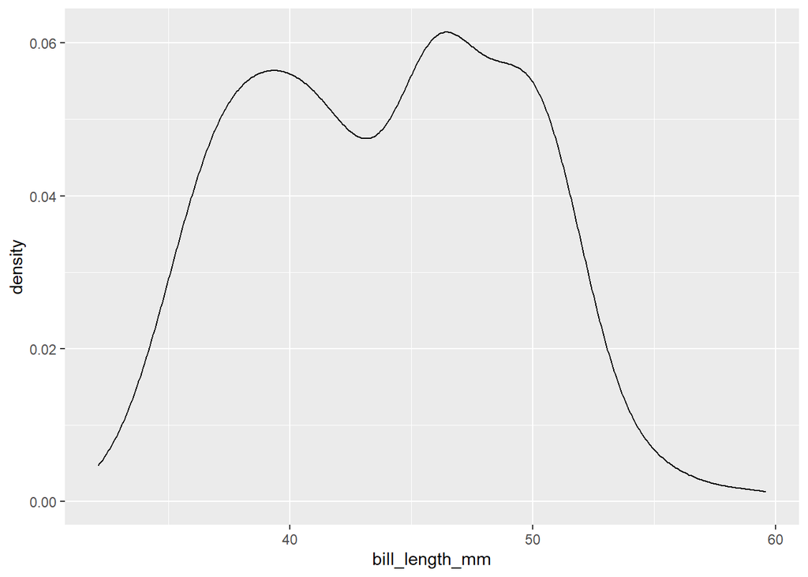

```r
ggplot(data = penguins,
       mapping = aes(x = bill_length_mm)) +
  geom_density()
```

### Multiple categories

To plot the distribution of multiple categories of a variable, the `group` argument within the `aes()` function is used. Setting the `colour` of `fill` arguments to `species` would also split by achieve the same results with additional colours.

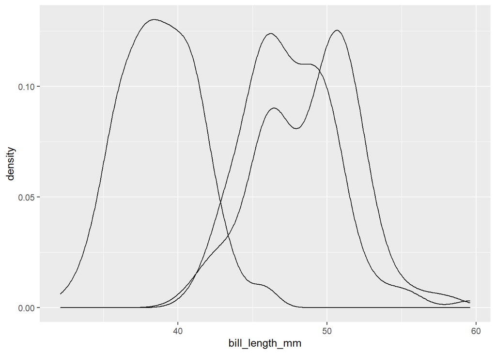

```r
ggplot(data = penguins,
       mapping = aes(x = bill_length_mm,
                     group = species)) +
  geom_density()
```

### Adding colour

There are two ways to add colour to density plots: (i) using `colour` (or `color`) which changes the colour of the outline of density plots; (ii) using `fill` which changes the colour of the inner area of the densities. If `colour` or `fill` is set outside the `aes()` function, it must be a valid colour name, and will set the same colour for all density plots. If `colour` or `fill` is set inside the `aes()` function, the colours will change based on the value of a variable. Here, the `fill` changes based on the `species`.

When plotting multiple densities on the same plot, it is often a good idea to increase the transparency of the fill colour to make sure that all layers can be seen. This is achieved using the `alpha` argument within `geom_density()`. Since the same transparency is desired for all density plots, it is set outside the `aes()` function. An `alpha` value of `0` is completely transparent, whilst a value of `1` is solid colour.

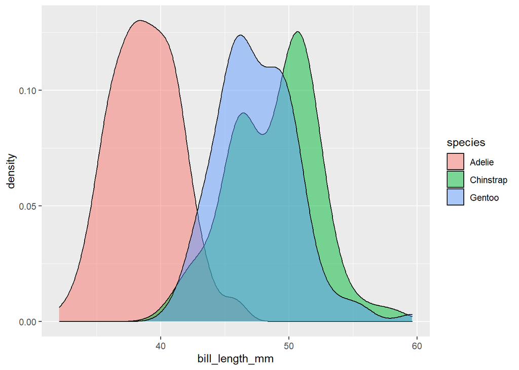

```r
ggplot(data = penguins,
       mapping = aes(x = bill_length_mm,
                     group = species,
                     fill = species)) +
  geom_density(alpha = 0.5)
```

### Facetting

Rather than displaying multiple distributions on the **same** plot, `facet_wrap()` can be used to **facet** the density plots and create a separate plot for each category. Note the `vars()` function wrapping around the variable when specifying the facet categories.

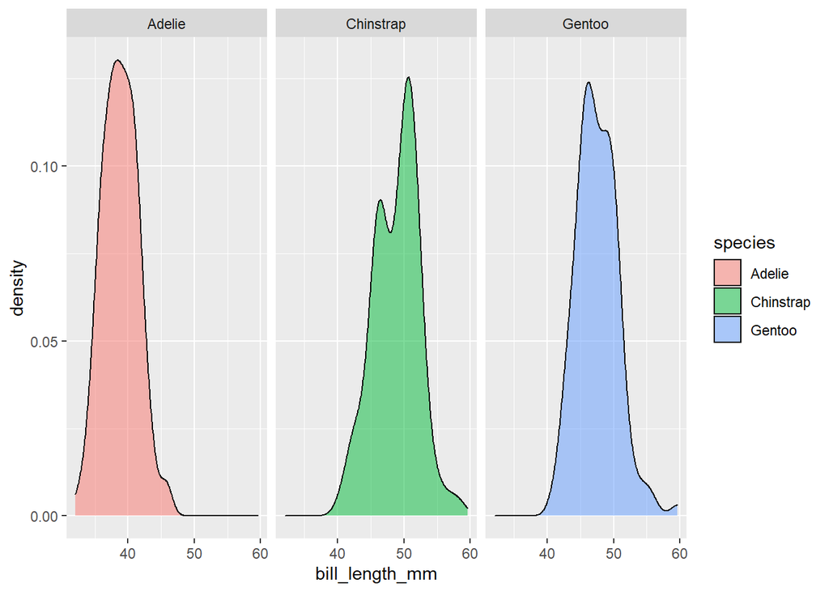

```r
ggplot(data = penguins,
       mapping = aes(x = bill_length_mm,
                     fill = species)) +
  geom_density(alpha = 0.5) +
  facet_wrap(facets = vars(species))
```

### Final version

Since the `fill` colours change in the same way as the values on the facets, a legend is not needed in this plot. The legend can be hidden using `theme(legend.position = "none")`. A title, subtitle, caption, and axis titles are set through the `labs()` function. The built-in minimalist {ggplot2} theme is added in here using `theme_minimal()`.

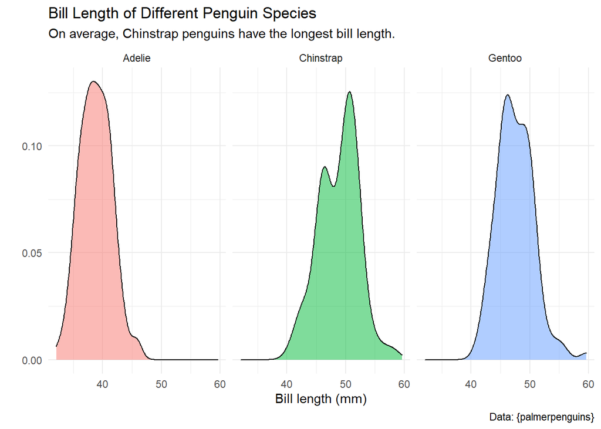

```r
ggplot(data = penguins,
       mapping = aes(x = bill_length_mm,
                     fill = species)) +
  geom_density(alpha = 0.5) +
  facet_wrap(~ species) +
  theme_minimal() +
  labs(title = "Bill Length of Different Penguin Species",
       subtitle = "On average, Chinstrap penguins have the longest bill length.",
       caption = "Data: {palmerpenguins}",
       x = "Bill length (mm)",
       y = "") +
  theme(legend.position = "none")
```